# Problem Set 6

Author

Published

Invalid Date

```r
# load packages, they are all installed for you already (in the cloud only)
library(tidyverse) # your friend and mine
library(broom) # for tidy regression
library(modelsummary) # for nice regression tables
library(fixest) # for fixed effects and 2SLS/IV regression
library(car) # for f-test
```

# Theory and Concepts

## Question 1

In your own words, describe what *fixed effects* are, when we can use them, and how they remove endogeneity.

## Question 2

In your own words, describe the logic of a *difference-in-difference* model: what is it comparing against what, and how does it estimate the effect of treatment? What assumption must be made about the treatment and control group for the model to be valid?

## Question 3

In your own words, describe the logic of an *instrumental variables* model: how does this approach identify the causal effect of $X$ on $Y$? What makes for a valid instrument? When using a Two-Stage Least Squares approach, what is estimated at each stage?

# R Questions

Answer the following questions using `R`. When necessary, please write answers in the same document (rendered to `html` or `pdf`, typed `.doc(x)`, or handwritten) as your answers to the above questions. Be sure to include (email or print an `.R` file, or show in your rendered quarto document) your code and the outputs of your code with the rest of your answers.

## Question 4 (Fixed Effects)

- [`PeaceCorps.csv`](http://metricsf22.classes.ryansafner.com/files/data/PeaceCorps.csv)

Download and read in `PeaceCorps.csv` dataset. If you don’t want to download/upload it, you can read it in directly from the url by running this chunk:

```r
# run or edit this chunk
pc <- read_csv("http://metricsf22.classes.ryansafner.com/files/data/PeaceCorps.csv")
```

How do people respond to changes in economic conditions? Are they more likely to pursue public service when private sector jobs are scarce? This dataset contains variables at the U.S. State (& D.C.) level:

| Variable | Description |
| --- | --- |
| `state` | U.S. State |
| `year` | Year |
| `appspc` | Applications to the Peace Corps (per capita) in State |
| `unemployrate` | State unemployment rate |

**Do more people apply to the Peace Corps when unemployment increases (and reduces other opportunities)?**

### Part A

Before looking at the data, what does your economic intuition tell you? Explain your hypothesis.

### Part B

To get the hang of the data we’re working with, `count` (separately) the number of `state`s, and the number of `year`s. Get the number of `n_distinct()` `state`s and `year`s (Do these inside the `summarize()` command), as well as the `distinct()` values of each (don’t use the `summarize()` command for this part).

```r
# write your code in this chunk
pc|>count(state)
```

| state | n |
| --- | --- |
| ALABAMA | 6 |
| ALASKA | 6 |
| ARIZONA | 6 |
| ARKANSAS | 6 |
| CALIFORNIA | 6 |
| COLORADO | 6 |
| CONNECTICUT | 6 |
| DELAWARE | 6 |
| DISTRICT OF COLUMBIA | 6 |
| FLORIDA | 6 |

[output cut: 41 more lines]

```r
pc|>count(year)
```

| year | n |
| --- | --- |
| 2006 | 51 |
| 2007 | 51 |
| 2008 | 51 |
| 2009 | 51 |
| 2010 | 51 |
| 2011 | 51 |

```r
pc|>summarise(n_distinct(state),n_distinct(year))
```

| n_distinct(state) | n_distinct(year) |
| --- | --- |
| 51 | 6 |

```r
pc|>distinct(state)
```

| state |
| --- |
| ALABAMA |
| ALASKA |
| ARIZONA |
| ARKANSAS |
| CALIFORNIA |
| COLORADO |
| CONNECTICUT |
| DELAWARE |
| DISTRICT OF COLUMBIA |
| FLORIDA |

[output cut: 41 more lines]

### Part C

Create a scatterplot of `appspc` (Y) on `unemployrate` (X). Which State is an outlier? How would this affect the pooled regression estimates? Create a *second* scatterplot that does not include this State.

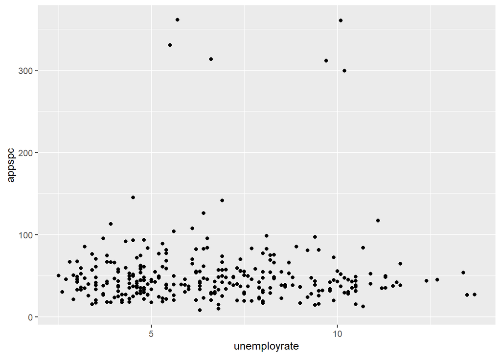

```r
# write your code in this chunk
ggplot(pc)+aes(x=unemployrate,y=appspc)+geom_point()
```

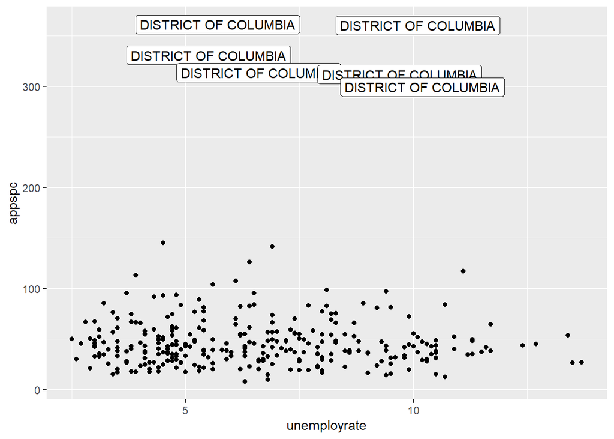

```r
ggplot(pc)+aes(x=unemployrate,y=appspc)+geom_point()+geom_label(data=pc|>filter(appspc>200),aes(label=state))
```

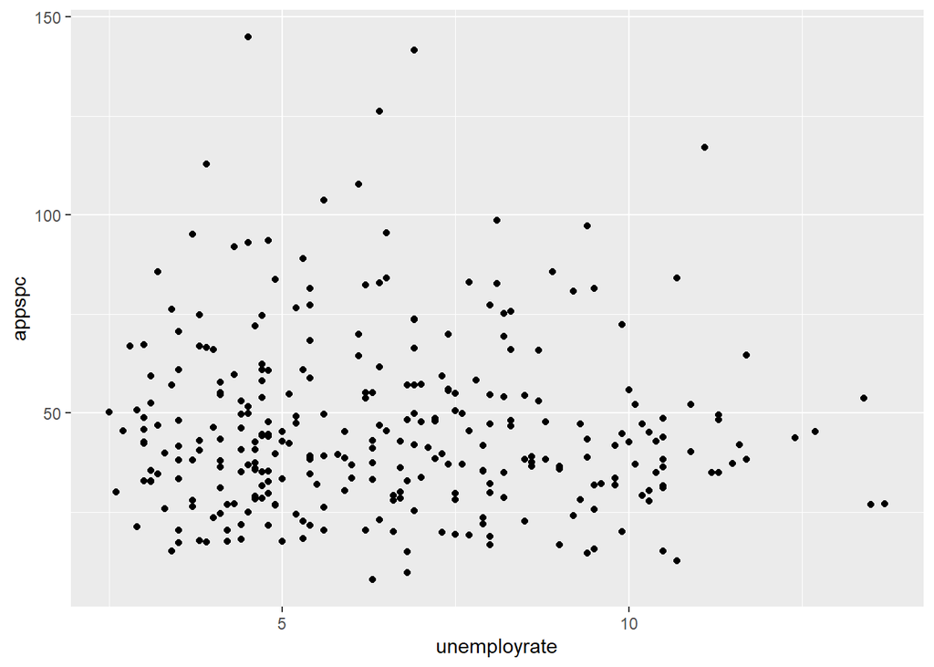

```r
pc1<-pc|>filter(appspc<200)
  ggplot(pc1)+aes(x=unemployrate,y=appspc)+geom_point()
```

### Part D

Run two *pooled* regressions, one with the outliers, and one without them. Write out the estimated regression equation for each. Interpret the coefficient, and comment on how it changes between the two regressions.

```r
# write your code in this chunk
POL<-lm(appspc~unemployrate,data=pc)
POL_nooutlier<-lm(appspc~unemployrate,data=pc1)
tidy(POL)
```

| term | estimate | std.error | statistic | p.value |
| --- | --- | --- | --- | --- |
| (Intercept) | 46.2255400 | 7.285678 | 6.3447138 | 8.071522e-10 |
| unemployrate | 0.8352609 | 1.036171 | 0.8061033 | 4.208134e-01 |

```r
tidy(POL_nooutlier)
```

| term | estimate | std.error | statistic | p.value |
| --- | --- | --- | --- | --- |
| (Intercept) | 48.5890975 | 3.5954565 | 13.5140272 | 8.725764e-33 |
| unemployrate | -0.3710292 | 0.5132501 | -0.7229014 | 4.703074e-01 |

### Part E

Now run a regression with State fixed effects using the dummy variable method. (Ensure that `state` is a factor variable, and insert in the regression. You can either `mutate()` it into a `factor` beforehand, or just do `factor(state)` in the `lm` command.) Interpret the marginal effect of `unemployrate` on `appspc`. How did it change?

```r
# write your code in this chunk
fe<-lm(appspc~unemployrate+factor(state),data=pc)
tidy(fe)
```

| term | estimate | std.error | statistic | p.value |
| --- | --- | --- | --- | --- |
| (Intercept) | 12.6069917 | 3.7662557 | 3.3473542 | 9.394824e-04 |
| unemployrate | 0.6565094 | 0.2330339 | 2.8172273 | 5.224730e-03 |
| factor(state)ALASKA | 52.5875065 | 4.8451654 | 10.8536041 | 8.503064e-23 |
| factor(state)ARIZONA | 18.0456284 | 4.8463421 | 3.7235565 | 2.419877e-04 |
| factor(state)ARKANSAS | 4.9116564 | 4.8446688 | 1.0138271 | 3.116300e-01 |
| factor(state)CALIFORNIA | 22.1455172 | 4.8691968 | 4.5480842 | 8.389183e-06 |
| factor(state)COLORADO | 69.9200520 | 4.8452292 | 14.4307007 | 7.003167e-35 |
| factor(state)CONNECTICUT | 28.9348689 | 4.8445987 | 5.9726039 | 7.839675e-09 |
| factor(state)DELAWARE | 21.8316546 | 4.8489139 | 4.5023803 | 1.024590e-05 |
| factor(state)DISTRICT OF COLUMBIA | 311.7035985 | 4.8532922 | 64.2251875 | 4.707707e-159 |

[output cut: 42 more lines]

### Part F

Find the coefficient for Maryland and interpret it. How many applications per capita does Maryland have?

```r
# write your code in this chunk
# if we want to extract it using R
fe_reg_tidy <- tidy(fe)

AL <- fe_reg_tidy %>%
  filter(term == "(Intercept)") %>%
  pull(estimate)

MD_AL_diff <- fe_reg_tidy %>%
  filter(term == "factor(state)MARYLAND") %>%
  pull(estimate)

MD_AL_diff
```

```
[1] 45.19032
```

### Part G

Now try using the `feols()` command (from the `fixest` package), which de-means the data, and make sure you get the same results as Part E. Do you get the same marginal effect of `unemployrate` on `appspc`?

```r
# write your code in this chunk
demeaned<-feols(appspc~unemployrate|factor(state),data=pc)
tidy(demeaned)
```

| term | estimate | std.error | statistic | p.value |
| --- | --- | --- | --- | --- |
| unemployrate | 0.6565094 | 0.1774436 | 3.69982 | 0.0005373892 |

### Part H

Now also include *year* fixed effects in your regression, using the dummy variable method. Interpret the marginal effect of `unemployrate` on `appspc`. How did it change?

```r
# write your code in this chunk
TWFE_reg <- lm(appspc ~ unemployrate + factor(state) + factor(year), data = pc)
summary(TWFE_reg)
```

```
Call:
lm(formula = appspc ~ unemployrate + factor(state) + factor(year),
    data = pc)

Residuals:
     Min       1Q   Median       3Q      Max
-26.7457  -3.1669   0.1384   2.7666  31.1644

Coefficients:
                                   Estimate Std. Error t value Pr(>|t|)
(Intercept)                        14.48800    3.91879   3.697 0.000268 ***
unemployrate                        0.70525    0.54733   1.289 0.198760
factor(state)ALASKA                52.57126    4.08265  12.877  < 2e-16 ***
factor(state)ARIZONA               18.01801    4.09035   4.405 1.57e-05 ***
factor(state)ARKANSAS               4.91897    4.07940   1.206 0.229036
factor(state)CALIFORNIA            22.04317    4.23743   5.202 4.12e-07 ***
factor(state)COLORADO              69.93711    4.08307  17.129  < 2e-16 ***
factor(state)CONNECTICUT           28.93000    4.07894   7.093 1.36e-11 ***
factor(state)DELAWARE              21.87470    4.10713   5.326 2.24e-07 ***
factor(state)DISTRICT OF COLUMBIA 311.64268    4.13555  75.357  < 2e-16 ***
factor(state)FLORIDA               13.03582    4.10931   3.172 0.001702 **
factor(state)GEORGIA               18.66589    4.10502   4.547 8.50e-06 ***
factor(state)HAWAII                35.87361    4.18953   8.563 1.16e-15 ***
factor(state)IDAHO                 34.48472    4.10104   8.409 3.24e-15 ***
factor(state)ILLINOIS              27.80635    4.11635   6.755 1.00e-10 ***
factor(state)INDIANA               21.48091    4.10010   5.239 3.44e-07 ***
factor(state)IOWA                  28.98828    4.18745   6.923 3.75e-11 ***
factor(state)KANSAS                29.02399    4.11886   7.047 1.79e-11 ***
factor(state)KENTUCKY               9.59010    4.14017   2.316 0.021351 *
factor(state)LOUISIANA              2.57585    4.12547   0.624 0.532951
factor(state)MAINE                 53.35320    4.08152  13.072  < 2e-16 ***
factor(state)MARYLAND              45.24393    4.12277  10.974  < 2e-16 ***
factor(state)MASSACHUSETTS         44.95986    4.08187  11.015  < 2e-16 ***
factor(state)MICHIGAN              26.72242    4.41044   6.059 5.03e-09 ***
factor(state)MINNESOTA             45.65107    4.09827  11.139  < 2e-16 ***
factor(state)MISSISSIPPI           -5.71925    4.18336  -1.367 0.172813
factor(state)MISSOURI              19.91937    4.08656   4.874 1.95e-06 ***
factor(state)MONTANA               66.30488    4.16773  15.909  < 2e-16 ***
factor(state)NEBRASKA              26.83099    4.36996   6.140 3.24e-09 ***
factor(state)NEVADA                12.59989    4.28489   2.941 0.003585 **
```

[output cut: 18 more lines]

```
factor(state)WASHINGTON            63.84082    4.08836  15.615  < 2e-16 ***
factor(state)WEST VIRGINIA          3.97742    4.08900   0.973 0.331641
factor(state)WISCONSIN             35.90359    4.08029   8.799 2.35e-16 ***
factor(state)WYOMING               35.40021    4.22056   8.388 3.73e-15 ***
factor(year)2007                   -5.36842    1.39953  -3.836 0.000159 ***
factor(year)2008                    0.02018    1.48030   0.014 0.989135
factor(year)2009                    4.23877    2.61984   1.618 0.106939
factor(year)2010                   -3.25521    2.76284  -1.178 0.239836
factor(year)2011                   -8.88542    2.47990  -3.583 0.000409 ***
---
Signif. codes:  0 '***' 0.001 '**' 0.01 '*' 0.05 '.' 0.1 ' ' 1

Residual standard error: 7.064 on 249 degrees of freedom
Multiple R-squared:   0.98, Adjusted R-squared:  0.9756
F-statistic: 218.3 on 56 and 249 DF,  p-value: < 2.2e-16
```

### Part I

What would be the predicted number of applications in Maryland in 2011 at an unemployment rate of 5%?

```r
# write your code in this chunk
```

### Part J

Now try using the `feols()` command, which de-means the data, and make sure you get the same results as Part H. Do you get the same marginal effect of `unemployrate` on `appspc`?

```r
# write your code in this chunk
```

### Part K

Can there still be endogeneity in this model? Give some examples.

### Part L

Create a nice regression table (using `modelsummary`) for comparison of the regressions in Parts D, G, and J.

```r
# write your code in this chunk
```

## Question 5 (Difference-in-Differences)

- [`TexasSchools.csv`](http://metricsf22.classes.ryansafner.com/files/data/TexasSchools.csv)

Download and read in `TexasSchools.csv` dataset. If you don’t want to download/upload it, you can read it in directly from the url by running this chunk:

```r
# run or edit this chunk
schools <- read_csv("http://metricsf22.classes.ryansafner.com/files/data/TexasSchools.csv")
```

Are teachers paid more when school board members are elected “off cycle” when there are not major national political elections (e.g. odd years) than “on cycle?” The argument is that during “off” years, without attention on state or national elections, voters will pay less attention to the election, and teachers can more effectively mobilize for higher pay, versus “on” years where voters are paying more attention. This data comes from Anzia, Sarah (2012), “The Election Timing Effect: Evidence from a Policy Intervention in Texas.” *Quarterly Journal of Political Science* 7(3): 277-297, and follows 1,020 Texas school board districts from 2003–2009.

From 2003–2006, all districts elected their school board members off-cycle. A change in Texas policy in 2006 led some, but not all, districts to elect their school board members on-cycle from 2007 onwards.

| Variable | Description |
| --- | --- |
| `LnAvgSalary` | logged average salary of teachers in district |
| `Year` | Year |
| `OnCycle` | `=1` if school boards elected on-cycle (e.g. same year as national and state elections), `=0` if elected off-cycle |
| `pol_freedom` | Political freedom index score (2018) from 1 (least) top 10 (most free) |
| `CycleSwitch` | `=1` if district switched from off- to on-cycle elections |
| `AfterSwitch` | `=1` if year is after 2006 |

### Part A

Run a pooled regression model of `LnAvgSalary` on `OnCycle`. Write the estimated regression equation, and interpret the coefficient on `OnCycle.` Are there any sources of bias (consider in particular the argument in the question prompt)?

```r
# write your code in this chunk
```

### Part B

Some schools decided to switch to an on-cycle election after 2006. Consider this, `CycleSwitch` the “treatment.” Create a variable to indicate post-treatment years (i.e. years after 2006). Call it `After`. Create a second, *interaction* variable to capture the interaction effect between those districts that *switched*, and *after* the treatment.

```r
# write your code in this chunk
```

### Part C

Now estimate a difference-in-difference model with your variables in Part B: `CycleSwitch` is the treatment variable, `After` is your post-treatment indicator, and add an *interaction* variable to capture the interaction effect between those districts that *switched*, and *after* the treatment. Write down the estimated regression equation (to four decimal places).

```r
# write your code in this chunk
```

### Part D

Interpret what each coefficient means from Part C.

### Part E

Using your regression equation in Part C, calculate the expected logged average salary $(Y)$ for districts in Texas:

1. *Before* the switch that did *not* switch
2. *After* the switch that did *not* switch
3. *Before* the switch that *did* switch
4. *After* the switch that *did* switch

### Part F

Confirm your estimates in Part E by finding the mean logged average salary for each of those four groups in the data. (Hint, `filter()` properly then `summarize()`.)

```r
# write your code in this chunk
```

### Part G

Write out the difference-in-difference equation, and calculate the difference-in-difference. Make sure it matches your estimate from the regression.

### Part H

Can we say anything about the types of districts that switched? Can we say anything about all salaries in the districts in the years after the switch?

### Part I

Now let’s generalize the diff-in-diff model. Instead of the treatment and post-treatment dummies, use district-and year-fixed effects and the interaction term. Interpret the coefficient on the interaction term.

This is doable with the dummy variable method, but there will be a *lot* of dummies! I suggest using `feols()` from the `fixest` package.

```r
# write your code in this chunk
```

### Part J

Create a nice regression table (using `modelsummary`) for comparison of the regressions in Parts A, C, and I.

```r
# write your code in this chunk
```

## Question 6 (Instrumental Variables)

### Part A

- [`RainIV.csv`](http://metricsf22.classes.ryansafner.com/files/data/RainIV.csv)

Download and read in `RainIV.csv` dataset. If you don’t want to download/upload it, you can read it in directly from the url by running this chunk:

```r
# run or edit this chunk
ivrain <- read_csv("http://metricsf22.classes.ryansafner.com/files/data/RainIV.csv")
```

Does economic growth reduce the odds of civil conflict? Consider data on 41 African countries between 1981-1999. Below are key variables (among others in the data):

| Variable | Description |
| --- | --- |
| `Internalconflict` | `=1` if civil war (<25 deaths), else `=0` |
| `LaggedGDPGrowth` | GDP Growth rate from previous year |
| `LagggedRainfallGrowth` | Change (in mm) of rain from previous year |
| `InitialGDP` | GDP per capita (1979) |
| `Democracy` | Polity II score |
| `country_name` | Country name |
| `country_code` | Three letter ISO country code |
| `year` | Year |
| `pop` | Population |
| `Mountains` | Percentage of territory that is mountainous terrain |
| `EthnicFrac` | Ethnic fractionalization index (probability two random individuals are NOT from the same ethnic group) |
| `ReligiousFrac` | Religious fractionalization index (probability two random individuals are NOT from the same religion) |

### Part A

Make a scatterplot between `Internalconflict` (as `y`) and `LaggedGDPGrowth` (as `x`), and add a regression line.

```r
# write your code in this chunk
```

### Part B

Run a regression of Internalconflict`on`LaggedGDPGrowth.` Note that since $Y$ is a dummy variable, $\beta_1$ is the probability of internal conflict in country $i$ at time $t$.

```r
# write your code in this chunk
```

### Part C

Run another regression, adding in `LaggedGDPGrowth`, `InitialGDP`, `Democracy`, `Mountains` `EthnicFrac`, and `ReligiousFrac` as controls. What happens to the marginal effect of `LaggedGDPGrowth`?

```r
# write your code in this chunk
```

### Part D

Now let’s consider `LaggedRainfallGrowth` as a potential instrument for `LaggedGDPGrowth`. First, check the correlations between `InternalConflict`, `LaggedGDPGrowth` and `LaggedRainfallGrowth`.

```r
# write your code in this chunk
```

### Part E

Now let’s consider if `LaggedRainfallGrowth` is a **relevant** instrument (the “inclusion condition”) by running the *first stage* regression of `LaggedGDPGrowth` on `LaggedRainfallGrowth` and the rest of the controls from part C. Is the OLS estimate on `LaggedRainfallGrowth` statistically significant?

```r
# write your code in this chunk
```

### Part F

There is no statistical test for whether `LaggedRainfallGrowth` is exogenous (the “exclusion condition”). Do you think it is plausible that `LaggedRainfallGrowth` is uncorrelated with the error term; that is, with any other factors that cause conflict; and that it **only** affects conflict through economic growth?

### Part G

Extract and save the fitted values of your first stage regression from part E. Now run the *second stage* regression by using the fitted values of `LaggedGDPGrowth` and the control variables from parts C and E. What is the marginal effect of `LaggedGDPGrowth` on `InternalConflict`?

```r
# write your code in this chunk
```

### Part H

Now run the same regression using `feols()` from the `fixest` package.

```r
# write your code in this chunk
```

### Part I

Make a nice regression table using `modelsummary()` using your results from Parts B, G, and H.

```r
# write your code in this chunk
```